# Synthea COVID-19 Module Analysis

This notebook provides and analysis of data generated by [Synthea](https://synthetichealth.github.io/synthea/)'s COVID-19 module. Analysis is run on the CSV output from Synthea.

Code in this notebook depends on [Pandas](https://pandas.pydata.org/), [NumPy](https://numpy.org/), [matplotlib](https://matplotlib.org/) and [seaborn](https://seaborn.pydata.org/).

```python
import pandas as pd
import numpy as np
import matplotlib.pyplot as plt
import matplotlib.ticker as ticker
import seaborn as sns
import datetime
```

```python
%matplotlib inline
```

```python
%config InlineBackend.figure_format = 'retina'
```

```python
%load_ext autoreload
```

```python
%autoreload 1
```

This jupyter notebook evolved over the creation of the Synthea COVID-19 Module. Initially, all python code was in the notebook. Eventually, this became unwieldy and code was moved into the imported file below.

```python
%aimport analysis
```

Read in all of the data

```python
conditions = pd.read_csv("conditions.csv")
patients = pd.read_csv("patients.csv")
observations = pd.read_csv("observations.csv")
care_plans = pd.read_csv("careplans.csv")
encounters = pd.read_csv("encounters.csv")
devices = pd.read_csv("devices.csv")
supplies = pd.read_csv('supplies.csv')
procedures = pd.read_csv("procedures.csv")
medications = pd.read_csv("medications.csv")
```

Grab the IDs of patients that have been diagnosed with COVID-19

```python
covid_patient_ids = conditions[conditions.CODE == 840539006].PATIENT.unique()
```

This grabs every patient with a negative SARS-CoV-2 test. This will include patients who tested negative up front as well as patients that tested negative after leaving the hospital

```python
negative_covid_patient_ids = observations[(observations.CODE == '94531-1') & (observations.VALUE == 'Not detected (qualifier value)')].PATIENT.unique()
```

Grabs IDs for all patients that died in the simulation. This will be more than just COVID-19 deaths.

```python
deceased_patients = patients[patients.DEATHDATE.notna()].Id
```

Grabs IDs for patients that have completed the care plan for isolation at home.

```python
completed_isolation_patients = care_plans[(care_plans.CODE == 736376001) & (care_plans.STOP.notna()) & (care_plans.REASONCODE == 840539006)].PATIENT
```

Survivors are the union of those who have completed isolation at home or have a negative SARS-CoV-2 test.

```python
survivor_ids = np.union1d(completed_isolation_patients, negative_covid_patient_ids)
```

Grab IDs for patients with admission due to COVID-19

```python
inpatient_ids = encounters[(encounters.REASONCODE == 840539006) & (encounters.CODE == 1505002)].PATIENT
```

The number of inpatient survivors

```python
np.intersect1d(inpatient_ids, survivor_ids).shape
```

```
(14654,)
```

The number of inpatient non-survivors

```python
np.intersect1d(inpatient_ids, deceased_patients).shape
```

```
(3548,)
```

```python
inpatient_ids.shape
```

```
(18177,)
```

## Health outcomes experienced by COVID-19 patients

The following table shows different health outcomes that were experienced by COVID-19 patients during the course of the disease.

```python
analysis.outcome_table(inpatient_ids, survivor_ids, deceased_patients, conditions)
```

|  | outcome | total | percent of inpatient | survivors | percent survivors | non survivors | percent non survivors |
| --- | --- | --- | --- | --- | --- | --- | --- |
| 0 | Sepsis | 6945 | 0.381551 | 3419 | 0.233315 | 3526 | 0.993799 |
| 1 | Respiratory Failure | 8710 | 0.478519 | 5237 | 0.357377 | 3473 | 0.978861 |
| 2 | ARDS | 2401 | 0.131909 | 85 | 0.005800 | 2316 | 0.652762 |
| 3 | Heart Failure | 1434 | 0.078783 | 124 | 0.008462 | 1310 | 0.369222 |
| 4 | Septic Shock | 1746 | 0.095924 | 0 | 0.000000 | 1746 | 0.492108 |
| 5 | Coagulopathy | 1389 | 0.076310 | 91 | 0.006210 | 1298 | 0.365840 |
| 6 | Acute Cardiac Injury | 1288 | 0.070761 | 20 | 0.001365 | 1268 | 0.357384 |
| 7 | Acute Kidney Injury | 1252 | 0.068784 | 8 | 0.000546 | 1244 | 0.350620 |

## Lab values for COVID-19 patients

The following code presents lab values taken for COVID-19 patients. Values are separated into survivors and non survivors.

The first block of code selects lab values of interest from all observations in the simulation.

```python
lab_obs = observations[(observations.CODE == '48065-7') | (observations.CODE == '26881-3') |
                          (observations.CODE == '2276-4') | (observations.CODE == '89579-7') |
                          (observations.CODE == '2532-0') | (observations.CODE == '731-0') |
                          (observations.CODE == '14804-9')
                      ]
```

Select COVID-19 conditions out of all conditions in the simulation

```python
covid_conditions = conditions[conditions.CODE == 840539006]
```

Merge the COVID-19 conditions with the patients

```python
covid_patients = covid_conditions.merge(patients, how='left', left_on='PATIENT', right_on='Id')
```

Add an attribute to the DataFrame indicating whether this is a survivor or not.

```python
covid_patients['survivor'] = covid_patients.PATIENT.isin(survivor_ids)
```

Reduce the columns on the DataFrame to ones needed

```python
covid_patients = covid_patients[['START', 'PATIENT', 'survivor', 'CODE']]
```

Calculate attributes needed to support the plot. Also coerce all lab values into a numeric data type.

```python
covid_patients_obs = covid_patients.merge(lab_obs, on='PATIENT')
covid_patients_obs['START'] = pd.to_datetime(covid_patients_obs.START)
covid_patients_obs['DATE'] = pd.to_datetime(covid_patients_obs.DATE)
covid_patients_obs['lab_days'] = covid_patients_obs.DATE - covid_patients_obs.START
covid_patients_obs['days'] = covid_patients_obs.lab_days / np.timedelta64(1, 'D')
covid_patients_obs['VALUE'] = pd.to_numeric(covid_patients_obs['VALUE'], errors='coerce')
```

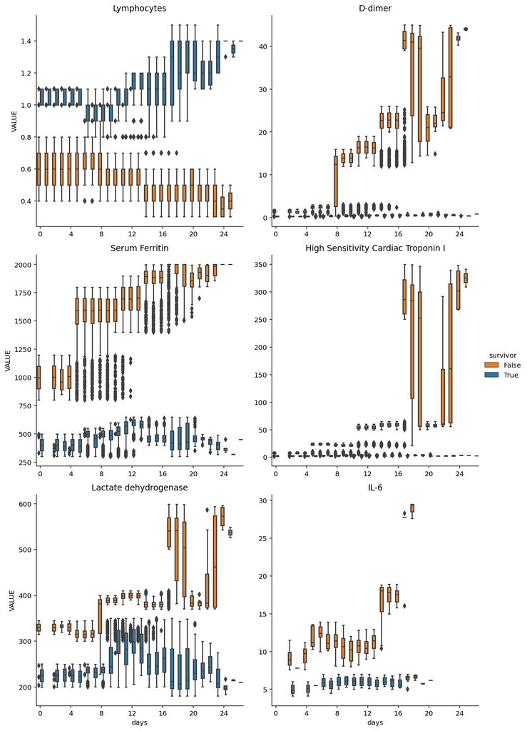

```python
loinc_to_display = {'CODE_y = 48065-7': 'D-dimer', 'CODE_y = 2276-4': 'Serum Ferritin',
                    'CODE_y = 89579-7': 'High Sensitivity Cardiac Troponin I',
                    'CODE_y = 26881-3': 'IL-6', 'CODE_y = 731-0': 'Lymphocytes',
                    'CODE_y = 14804-9': 'Lactate dehydrogenase'}
catplt = sns.catplot(x="days", y="VALUE", hue="survivor", kind="box", col='CODE_y',
            col_wrap=2, sharey=False, sharex=False, data=covid_patients_obs, palette=["C1", "C0"])

for axis in catplt.fig.axes:
    axis.xaxis.set_major_formatter(ticker.FormatStrFormatter('%d'))
    axis.xaxis.set_major_locator(ticker.MultipleLocator(base=4))
    axis.set_title(loinc_to_display[axis.title.get_text()])

plt.show()
```

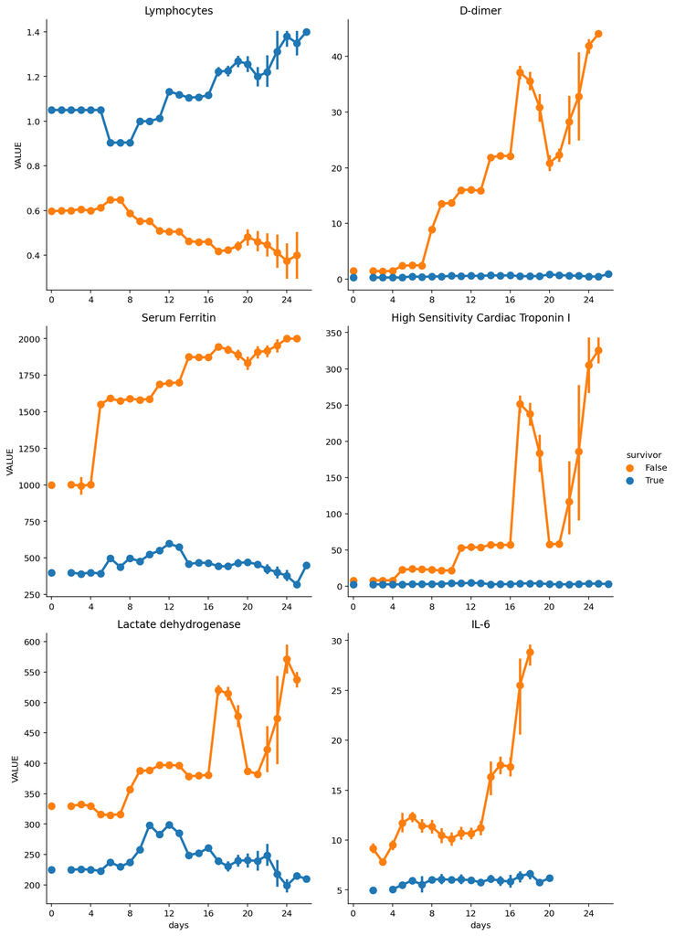

```python
loinc_to_display = {'CODE_y = 48065-7': 'D-dimer', 'CODE_y = 2276-4': 'Serum Ferritin',
                    'CODE_y = 89579-7': 'High Sensitivity Cardiac Troponin I',
                    'CODE_y = 26881-3': 'IL-6', 'CODE_y = 731-0': 'Lymphocytes',
                    'CODE_y = 14804-9': 'Lactate dehydrogenase'}
catplt = sns.catplot(x="days", y="VALUE", hue="survivor", kind="point", col='CODE_y',
            col_wrap=2, sharey=False, sharex=False, data=covid_patients_obs, palette=["C1", "C0"])

for axis in catplt.fig.axes:
    axis.xaxis.set_major_formatter(ticker.FormatStrFormatter('%d'))
    axis.xaxis.set_major_locator(ticker.MultipleLocator(base=4))
    axis.set_title(loinc_to_display[axis.title.get_text()])

plt.show()
```

Set up a new DataFrame with boolean columns representing various outcomes, like admit, recovery or death

```python
cp = covid_conditions.merge(patients, how='left', left_on='PATIENT', right_on='Id')
isolation_ids = care_plans[(care_plans.CODE == 736376001) & (care_plans.REASONCODE == 840539006)].PATIENT
cp['isolation'] = cp.Id.isin(isolation_ids)
cp['admit'] = cp.Id.isin(inpatient_ids)
cp['recovered'] = cp.Id.isin(survivor_ids)
cp['death'] = cp.DEATHDATE.notna()
icu_ids = encounters[encounters.CODE == 305351004].PATIENT
cp['icu_admit'] = cp.Id.isin(icu_ids)
vent_ids = procedures[procedures.CODE == 26763009].PATIENT
cp['ventilated'] = cp.Id.isin(vent_ids)
```

## Outcomes for all COVID-19 Patients

This code builds a new DataFrame for the purposes of display. The DataFrame contains the percentages of patients that experience a particular outcome. Percentages are then provided for only hospitalized patients, ICU admitted patients and ventilated patients.

```python
hospitalized = (cp.admit == True)
icu = (cp.icu_admit == True)
vent = (cp.ventilated == True)
covid_count = cp.Id.size
row_filters = {'Home Isolation': (cp.isolation == True), 'Hospital Admission': hospitalized, 'ICU Admission': icu,
 'Ventilated': vent, 'Recovered': (cp.recovered == True), 'Death': (cp.death == True)}

table_rows = []
for category, row_filter in row_filters.items():
    row = {'Outcome': category}
    row['All Patients'] = cp[row_filter].Id.size / covid_count
    row['Hospitalized'] = cp[row_filter & hospitalized].Id.size / hospitalized.value_counts()[True]
    row['ICU Admitted'] = cp[row_filter & icu].Id.size / icu.value_counts()[True]
    row['Required Ventilation'] = cp[row_filter & vent].Id.size / vent.value_counts()[True]
    table_rows.append(row)

pd.DataFrame.from_records(table_rows)
```

|  | Outcome | All Patients | Hospitalized | ICU Admitted | Required Ventilation |
| --- | --- | --- | --- | --- | --- |
| 0 | Home Isolation | 0.800036 | 0.029986 | 0.029644 | 0.028826 |
| 1 | Hospital Admission | 0.206145 | 1.000000 | 1.000000 | 1.000000 |
| 2 | ICU Admission | 0.041705 | 0.202311 | 1.000000 | 1.000000 |
| 3 | Ventilated | 0.033051 | 0.160330 | 0.792494 | 1.000000 |
| 4 | Recovered | 0.959724 | 0.806272 | 0.320914 | 0.148250 |
| 5 | Death | 0.041297 | 0.195103 | 0.679358 | 0.851750 |

## Outcomes for ICU Admitted Patients

Essentially a sub table from above, looking only at ICU patients.

```python
icu_only = cp[cp.icu_admit == True]

vent = (icu_only.ventilated == True)
covid_count = icu_only.Id.size
row_filters = {'Ventilated': vent, 'Recovered': (icu_only.recovered == True), 'Death': (icu_only.death == True)}

table_rows = []
for category, row_filter in row_filters.items():
    row = {'Outcome': category}
    row['ICU Admitted'] = icu_only[row_filter].Id.size / covid_count
    row['Required Ventilation'] = icu_only[row_filter & vent].Id.size / vent.value_counts()[True]
    table_rows.append(row)

pd.DataFrame.from_records(table_rows)
```

|  | Outcome | ICU Admitted | Required Ventilation |
| --- | --- | --- | --- |
| 0 | Ventilated | 0.792494 | 1.00000 |
| 1 | Recovered | 0.320914 | 0.14825 |
| 2 | Death | 0.679358 | 0.85175 |

Start to build a DataFrame that we can use to look at other conditions in relation to COVID-19

```python
covid_info = cp[['PATIENT', 'recovered', 'death', 'START', 'DEATHDATE', 'BIRTHDATE', 'GENDER', 'admit', 'icu_admit']]
```

```python
covid_info = covid_info.rename(columns={'START': 'covid_start'})
```

Grab all of the conditions starting after January 20, 2020. This is a hack to get only conditions that are related to COVID-19. We will end up merging these with the COVID patients.

```python
covid_related_conditions = conditions[pd.to_datetime(conditions.START) > pd.to_datetime('2020-01-20')]
```

This DataFrame will contain all conditions for COVID-19 patients, where `START` can be compared to `covid_start` to see how long after the COVID-19 diagnosis something happened.

```python
covid_patient_conditions = covid_info.merge(covid_related_conditions, on='PATIENT')
```

## Symptoms for all COVID-19 Patients

Generates a DataFrame with percentages of co-occurring conditions

```python
analysis.symptom_table(covid_patient_conditions)
```

|  | Symptoms | All Patients Percentage | All Patients Count | Survivor Percentage | Survivor Count | Non Survivor Percentage | Non Survivor Count |
| --- | --- | --- | --- | --- | --- | --- | --- |
| 0 | Conjunctival Congestion | 0.008371 | 738 | 0.007718 | 653 | 0.023895 | 87 |
| 1 | Nasal Congestion | 0.046257 | 4078 | 0.046697 | 3951 | 0.036254 | 132 |
| 2 | Headache | 0.137602 | 12131 | 0.136747 | 11570 | 0.158473 | 577 |
| 3 | Cough | 0.677892 | 59763 | 0.676346 | 57225 | 0.713540 | 2598 |
| 4 | Sore Throat | 0.140585 | 12394 | 0.140623 | 11898 | 0.138149 | 503 |
| 5 | Sputum Production | 0.336468 | 29663 | 0.336004 | 28429 | 0.346608 | 1262 |
| 6 | Fatigue | 0.383961 | 33850 | 0.383529 | 32450 | 0.393299 | 1432 |
| 7 | Hemoptysis | 0.009698 | 855 | 0.009006 | 762 | 0.026092 | 95 |
| 8 | Shortness of Breath | 0.198662 | 17514 | 0.191434 | 16197 | 0.367481 | 1338 |
| 9 | Nausea | 0.051032 | 4499 | 0.050467 | 4270 | 0.063444 | 231 |
| 10 | Diarrhea | 0.038929 | 3432 | 0.038176 | 3230 | 0.057127 | 208 |
| 11 | Muscle Pain | 0.150726 | 13288 | 0.149310 | 12633 | 0.184839 | 673 |
| 12 | Joint Pain | 0.150726 | 13288 | 0.149310 | 12633 | 0.184839 | 673 |
| 13 | Chills | 0.116629 | 10282 | 0.115295 | 9755 | 0.148036 | 539 |
| 14 | Loss of Taste | 0.506375 | 44642 | 0.506105 | 42821 | 0.512497 | 1866 |

## Symptoms for ICU admitted COVID-19 Patients

DataFrame limited to individuals admitted to the ICU

```python
analysis.symptom_table(covid_patient_conditions, True)
```

|  | Symptoms | All Patients Percentage | All Patients Count | Survivor Percentage | Survivor Count | Non Survivor Percentage | Non Survivor Count |
| --- | --- | --- | --- | --- | --- | --- | --- |
| 0 | Conjunctival Congestion | 0.022573 | 83 | 0.017797 | 21 | 0.024820 | 62 |
| 1 | Nasal Congestion | 0.037259 | 137 | 0.040678 | 48 | 0.035629 | 89 |
| 2 | Headache | 0.157193 | 578 | 0.140678 | 166 | 0.164932 | 412 |
| 3 | Cough | 0.717161 | 2637 | 0.722881 | 853 | 0.714572 | 1785 |
| 4 | Sore Throat | 0.132445 | 487 | 0.117797 | 139 | 0.139311 | 348 |
| 5 | Sputum Production | 0.345662 | 1271 | 0.339831 | 401 | 0.348279 | 870 |
| 6 | Fatigue | 0.403046 | 1482 | 0.422034 | 498 | 0.394315 | 985 |
| 7 | Hemoptysis | 0.026380 | 97 | 0.022881 | 27 | 0.028022 | 70 |
| 8 | Shortness of Breath | 0.375578 | 1381 | 0.394915 | 466 | 0.366693 | 916 |
| 9 | Nausea | 0.065271 | 240 | 0.069492 | 82 | 0.063251 | 158 |
| 10 | Diarrhea | 0.054392 | 200 | 0.054237 | 64 | 0.054444 | 136 |
| 11 | Muscle Pain | 0.178406 | 656 | 0.173729 | 205 | 0.180544 | 451 |
| 12 | Joint Pain | 0.178406 | 656 | 0.173729 | 205 | 0.180544 | 451 |
| 13 | Chills | 0.147131 | 541 | 0.144915 | 171 | 0.148118 | 370 |
| 14 | Loss of Taste | 0.527604 | 1940 | 0.539831 | 637 | 0.521617 | 1303 |

Create a DataFrame with columns that show a condition's start and end in days relative to COVID-19 diagnosis. Also create a column that calculates the number of days between COVID-19 diagnosis and a person's death.

```python
covid_patient_conditions['start_days'] = (pd.to_datetime(covid_patient_conditions.START) - pd.to_datetime(covid_patient_conditions.covid_start)) / np.timedelta64(1, 'D')
covid_patient_conditions['end_days'] = (pd.to_datetime(covid_patient_conditions.STOP) - pd.to_datetime(covid_patient_conditions.covid_start)) / np.timedelta64(1, 'D')
covid_patient_conditions['death_days'] = (pd.to_datetime(covid_patient_conditions.DEATHDATE) - pd.to_datetime(covid_patient_conditions.covid_start)) / np.timedelta64(1, 'D')
```

## Timelines for hospitalized patients

These plots show the progression of COVID-19 related complications in hospitalized patients. The bars represent the average start and end time for the particular item. Arrows at the bottom show the time or start time of a particular item.

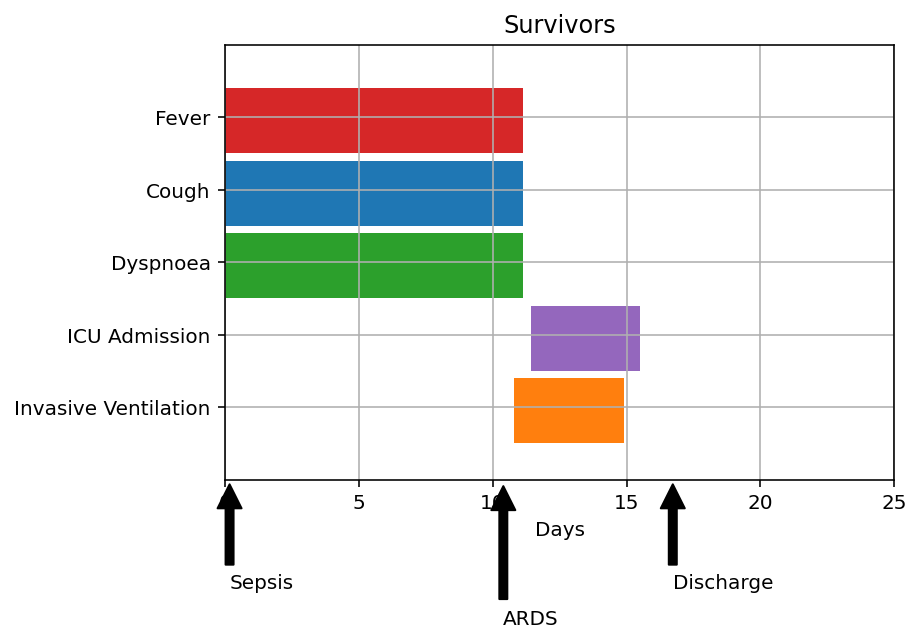

```python
averages = analysis.select_condition_averages(covid_patient_conditions, ((covid_patient_conditions.recovered == True) &
                                                               (covid_patient_conditions.admit == True)))
analysis.survivor_timeline_plot(encounters, devices, averages, covid_patient_conditions, covid_info)
```

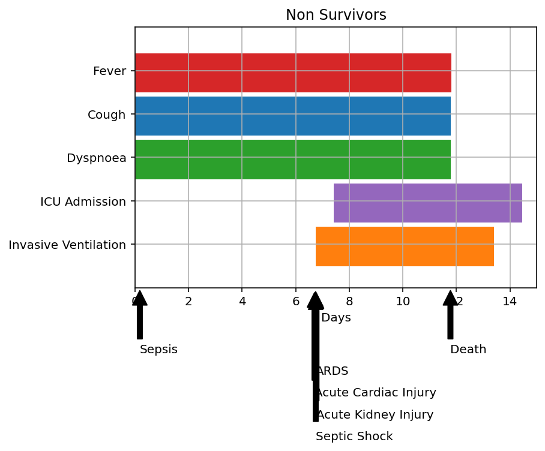

```python
averages = analysis.select_condition_averages(covid_patient_conditions, ((covid_patient_conditions.death == True) &
                                                               (covid_patient_conditions.admit == True)))
analysis.non_survivor_timeline_plot(encounters, devices, averages, covid_patient_conditions, covid_info)
```

## Timelines for ICU only patients

These plots refine the timelines to only patients with ICU admissions

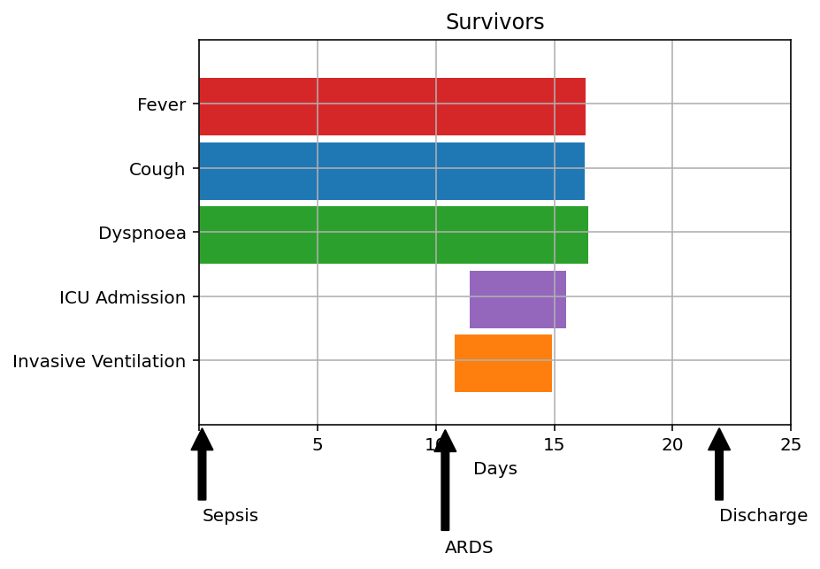

```python
averages = analysis.select_condition_averages(covid_patient_conditions, ((covid_patient_conditions.recovered == True) &
                                                               (covid_patient_conditions.icu_admit == True)))
analysis.survivor_timeline_plot(encounters, devices, averages, covid_patient_conditions, covid_info, True)
```

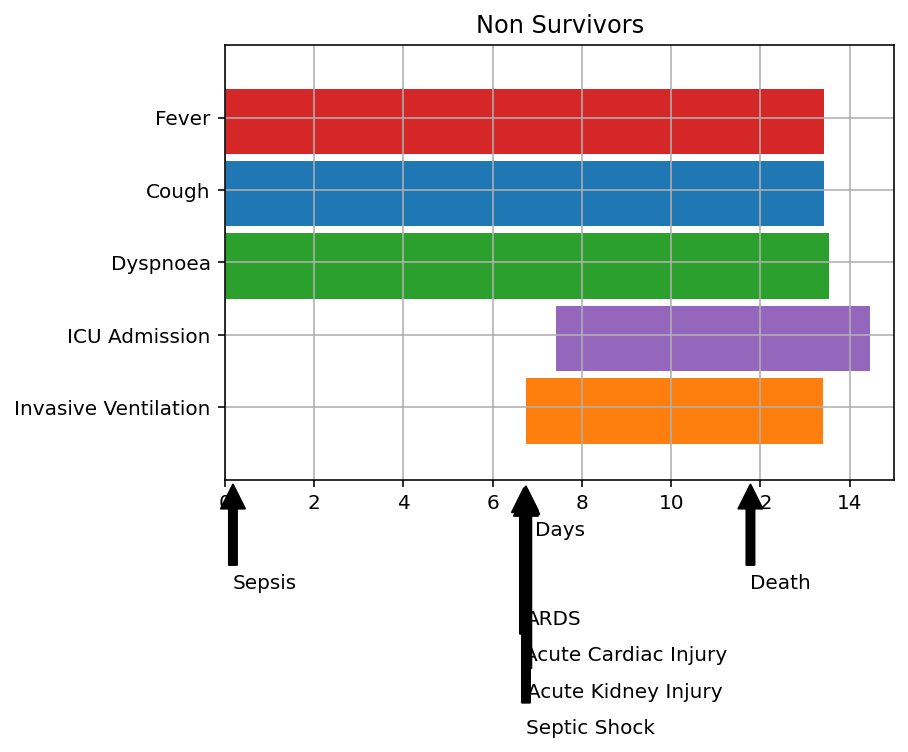

```python
averages = analysis.select_condition_averages(covid_patient_conditions, ((covid_patient_conditions.death == True) &
                                                               (covid_patient_conditions.icu_admit == True)))
analysis.non_survivor_timeline_plot(encounters, devices, averages, covid_patient_conditions, covid_info)
```

Add an age column to the DataFrame for rows where the patient has died

```python
covid_info.loc[covid_info.death == True, 'age'] = (pd.to_datetime(covid_info.DEATHDATE) - pd.to_datetime(covid_info.BIRTHDATE)) / np.timedelta64(1, 'Y')
```

Populate ages for survivors based on the current date

```python
covid_info.loc[covid_info.recovered == True, 'age'] = (datetime.datetime.now() - pd.to_datetime(covid_info.BIRTHDATE)) / np.timedelta64(1, 'Y')
```

Create an age_range column that places individuals into 10 year age ranges, such as 0 - 10, 10 - 20, etc.

```python
bins = list(range(0, 120, 10))
covid_info['age_range'] = pd.cut(covid_info.age, bins=bins)
```

## Mortality by Age and Sex

A plot of deaths grouped by age range and gender.

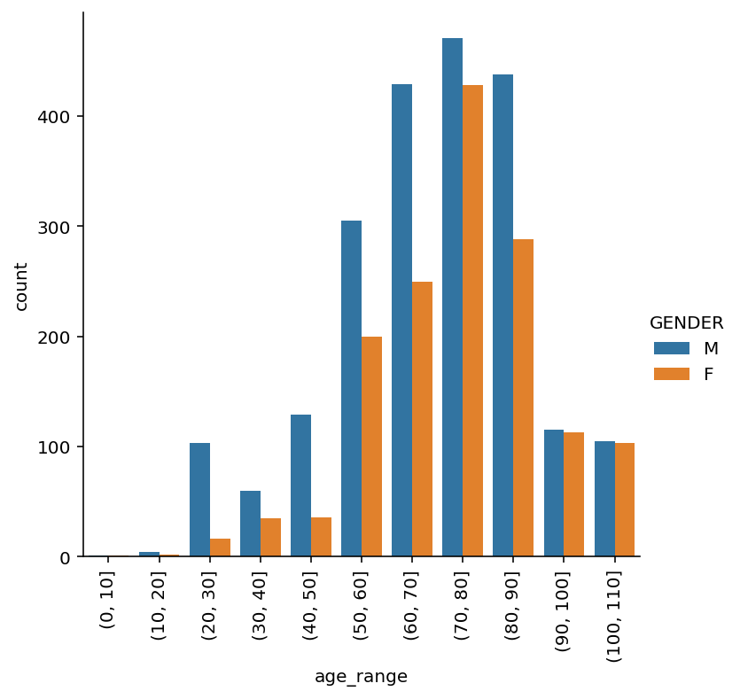

```python
chart = sns.catplot(x="age_range", kind="count", hue="GENDER", data=covid_info[covid_info.death==True]);
for axes in chart.axes.flat:
    axes.set_xticklabels(axes.get_xticklabels(), rotation=90)
```

A table view of the same information from above

```python
covid_info[covid_info.death==True].groupby(['age_range', 'GENDER']).count()[['PATIENT']]
```

| age_range | GENDER | PATIENT |
| --- | --- | --- |
| (0, 10] | F | 1 |
|  | M | 1 |
| (10, 20] | F | 2 |
|  | M | 4 |
| (20, 30] | F | 16 |
|  | M | 103 |
| (30, 40] | F | 35 |
|  | M | 60 |
| (40, 50] | F | 36 |
|  | M | 129 |
| (50, 60] | F | 200 |
|  | M | 305 |
| (60, 70] | F | 250 |
|  | M | 429 |
| (70, 80] | F | 428 |
|  | M | 471 |
| (80, 90] | F | 288 |
|  | M | 438 |
| (90, 100] | F | 113 |
|  | M | 115 |
| (100, 110] | F | 103 |
|  | M | 105 |

Another table view of the mortality data, this time just grouped by age range

```python
covid_info[covid_info.death==True].groupby(['age_range']).count()[['PATIENT']]
```

| age_range | PATIENT |
| --- | --- |
| (0, 10] | 2 |
| (10, 20] | 6 |
| (20, 30] | 119 |
| (30, 40] | 95 |
| (40, 50] | 165 |
| (50, 60] | 505 |
| (60, 70] | 679 |
| (70, 80] | 899 |
| (80, 90] | 726 |
| (90, 100] | 228 |
| (100, 110] | 208 |

Build a DataFrame that shows the total count of a supply used on a given day

```python
grouped_supplies = supplies.groupby(['DESCRIPTION', 'DATE']).sum()
```

## Supply Usage

Small multiples plot of supply usage over time.

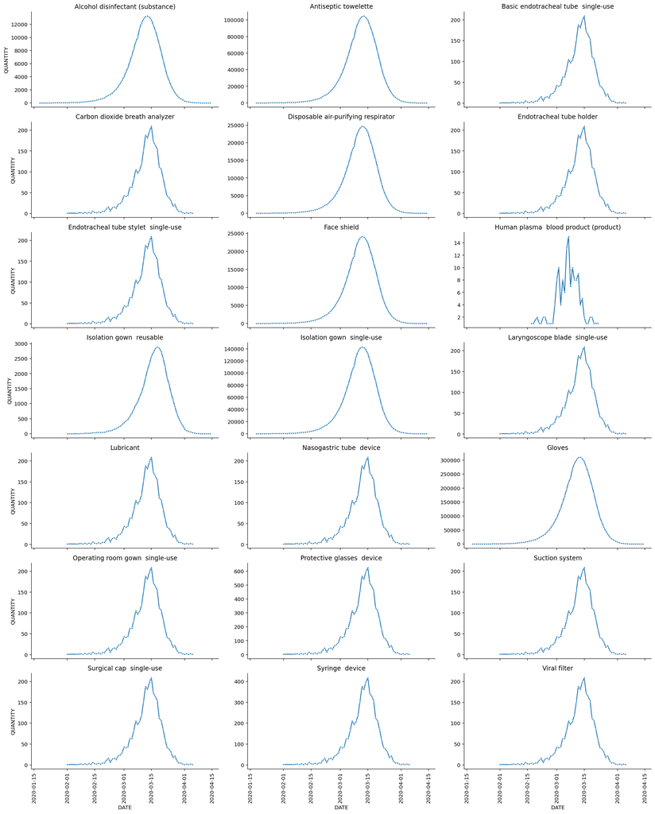

```python
gs = grouped_supplies.reset_index()
gs['DATE'] = pd.to_datetime(gs.DATE)
g = sns.FacetGrid(gs, col="DESCRIPTION", col_wrap=3, sharey=False, height=3, aspect=2)
g = g.map(sns.lineplot, "DATE", "QUANTITY", marker=".")
for axes in g.axes.flat:
    title = axes.get_title()
    if 'glove' in title:
        axes.set_title('Gloves')
    else:
        axes.set_title(title.replace("DESCRIPTION = ", "").replace(" (physical object)", ""))
    for tick in axes.get_xticklabels():
        tick.set_rotation(90)
```

A table showing total supplies used over the entire simulation

```python
supplies.groupby(['DESCRIPTION']).sum()[['QUANTITY']]
```

| DESCRIPTION | QUANTITY |
| --- | --- |
| Alcohol disinfectant (substance) | 245937 |
| Antiseptic towelette (physical object) | 1947098 |
| Basic endotracheal tube single-use (physical object) | 2914 |
| Carbon dioxide breath analyzer (physical object) | 2914 |
| Disposable air-purifying respirator (physical object) | 446438 |
| Endotracheal tube holder (physical object) | 2914 |
| Endotracheal tube stylet single-use (physical object) | 2914 |
| Face shield (physical object) | 437696 |
| Human plasma blood product (product) | 143 |
| Isolation gown reusable (physical object) | 48350 |
| Isolation gown single-use (physical object) | 2583654 |
| Laryngoscope blade single-use (physical object) | 2914 |
| Lubricant (physical object) | 2914 |
| Nasogastric tube device (physical object) | 2914 |
| Nitrile examination/treatment glove non-powdered sterile (physical object) | 5759164 |
| Operating room gown single-use (physical object) | 2914 |
| Protective glasses device (physical object) | 8742 |
| Suction system (physical object) | 2914 |
| Surgical cap single-use (physical object) | 2914 |
| Syringe device (physical object) | 5828 |
| Viral filter (physical object) | 2914 |

Build a DataFrame that has cumulative case counts over time

```python
case_counts = conditions[conditions.CODE == 840539006].groupby('START').count()[['PATIENT']]
case_counts['total'] = case_counts['PATIENT'].cumsum()
case_counts = case_counts.rename(columns={'PATIENT': 'daily'})
case_counts = case_counts.reset_index()
case_counts['START'] = pd.to_datetime(case_counts.START)
```

## Cumulative Case Count

Show total cases over time

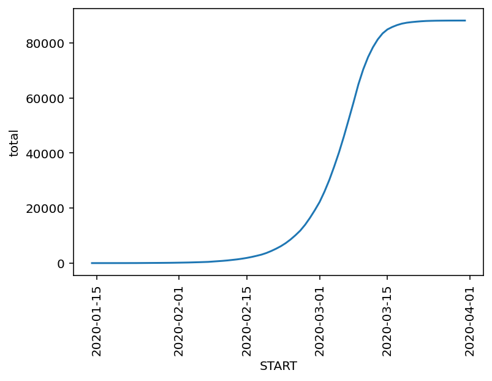

```python
axes = sns.lineplot(x='START', y='total', data=case_counts)
plt.xticks(rotation=90)
plt.show()
```

## Medication Dispenses

This table shows medications dispensed to patients with COVID-19 since January 20, 2020.

```python
covid_meds = medications[pd.to_datetime(medications.START) > pd.to_datetime('2020-01-20')]
covid_meds = covid_info.merge(covid_meds, on='PATIENT')
```

```python
covid_meds.groupby(['DESCRIPTION']).sum()[['DISPENSES']].sort_values('DISPENSES', ascending=False).head(10)
```

| DESCRIPTION | DISPENSES |
| --- | --- |
| Acetaminophen 500 MG Oral Tablet | 35509 |
| 0.4 ML Enoxaparin sodium 100 MG/ML Prefilled Syringe | 34733 |
| 1 ML Enoxaparin sodium 150 MG/ML Prefilled Syringe | 20332 |
| NDA020503 200 ACTUAT Albuterol 0.09 MG/ACTUAT Metered Dose Inhaler | 17163 |
| Hydrochlorothiazide 25 MG Oral Tablet | 6832 |
| Simvastatin 10 MG Oral Tablet | 5779 |
| insulin human isophane 70 UNT/ML / Regular Insulin Human 30 UNT/ML Injectable Suspension [Humulin] | 5392 |
| 1 ML Epoetin Alfa 4000 UNT/ML Injection [Epogen] | 4817 |
| amLODIPine 5 MG / Hydrochlorothiazide 12.5 MG / Olmesartan medoxomil 20 MG Oral Tablet | 4799 |
| Atenolol 50 MG / Chlorthalidone 25 MG Oral Tablet | 4550 |

## Hospital Day Stats

For patients with COVID-19, calculate the average hospital length of stay as well as total hospital days for all COVID-19 patients. Provide the same information for ICU patients

```python
covid_hosp = analysis.create_covid_hosp(covid_info, encounters, {'admit': True}).reset_index()
covid_icu = analysis.create_covid_icu(covid_info, encounters)
pd.DataFrame.from_records([
    {
        'type': 'inpatient',
        'patients': covid_hosp.PATIENT.nunique(),
        'average stay': ((covid_hosp.STOP - covid_hosp.START) / np.timedelta64(1, 'D')).mean(),
        'total days': ((covid_hosp.STOP - covid_hosp.START) / np.timedelta64(1, 'D')).sum(),
    },
    {
        'type': 'ICU',
        'patients': covid_icu.PATIENT.nunique(),
        'average stay': ((pd.to_datetime(covid_icu.STOP) - pd.to_datetime(covid_icu.START, utc=True)) / np.timedelta64(1, 'D')).mean(),
        'total days': ((pd.to_datetime(covid_icu.STOP) - pd.to_datetime(covid_icu.START, utc=True)) / np.timedelta64(1, 'D')).sum(),
    }
])
```

|  | type | patients | average stay | total days |
| --- | --- | --- | --- | --- |
| 0 | inpatient | 18175 | 15.033008 | 273224.918056 |
| 1 | ICU | 3677 | 6.086216 | 22379.015972 |

```python
device_codes = [448907002, 449071006, 36965003]
grouped_dev = devices[devices.CODE.isin(device_codes)].groupby(['DESCRIPTION', 'START']).count()
grouped_dev = grouped_dev.reset_index()
grouped_dev['START'] = pd.to_datetime(grouped_dev.START)
```

## Device Usage

Show the number of devices used to treat COVID-19 over time.

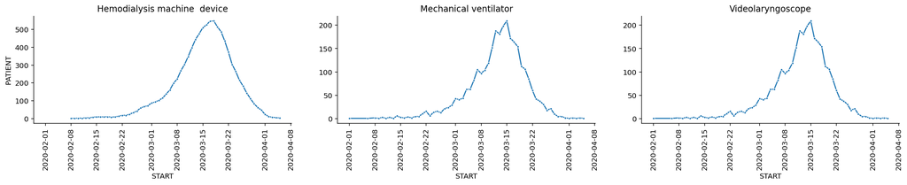

```python
g = sns.FacetGrid(grouped_dev.reset_index(), col="DESCRIPTION", col_wrap=3, sharey=False, height=3, aspect=2)
g = g.map(sns.lineplot, "START", "PATIENT", marker=".")
for axes in g.axes.flat:
    title = axes.get_title()
    axes.set_title(title.replace("DESCRIPTION = ", "").replace(" (physical object)", ""))
    for tick in axes.get_xticklabels():
        tick.set_rotation(90)
```